# PEC 2: Técnicas de Visualización de Datos

Adrián Moreno García

2026-10-30

# Representaciones gráficas de las diferentes técnicas

Muestro los diferentes gráficos que se me piden, para cada uno de ellos se utiliza su correspondiente dataset para ajustarse a las características de la representación.

## TÉCNICA GRUPO I (Básicas y populares): Treemap

**¿Cómo se reparte la riqueza en el mundo?**

Este Treemap interactivo (Gapminder 2007) jerarquiza la riqueza mundial asignando el tamaño de las cajas al PIB per cápita y el color en escala logarítmica a la población. Dirigido a analistas y tomadores de decisiones, busca evidenciar de forma inmediata el contraste entre potencias económicas pequeñas pero prósperas y gigantes demográficos de menor ingreso. El uso de la paleta Viridis, los bordes limpios y la interactividad por niveles (continente-país) permiten descubrir patrones globales de desigualdad socioeconómica sin sesgos visuales por valores extremos.

[interactive chart not shown]

## TÉCNICA GRUPO II (Habituales y específicas): Alluvial Diagram

**¿Mujeres y niños primero?**

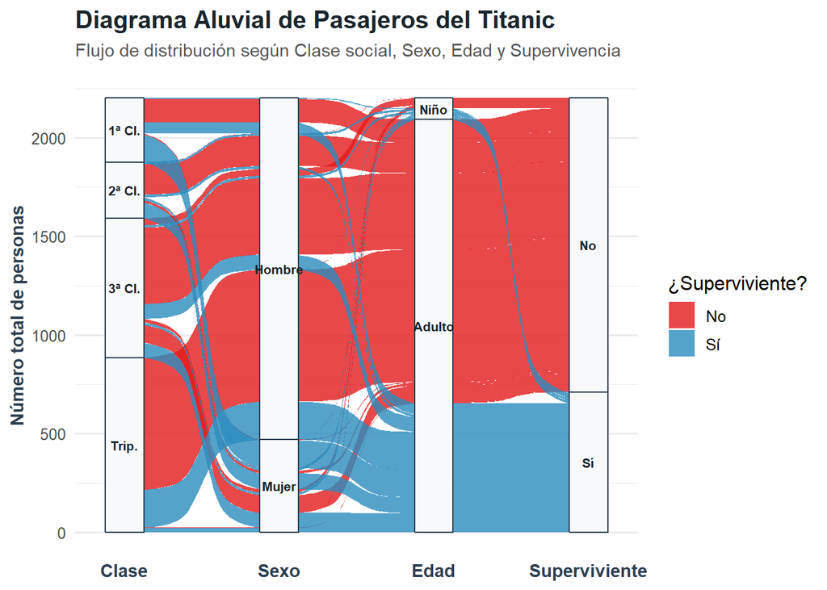

## TÉCNICA GRUPO III (Menos habituales o específicas): Contour plot

**Peligro bajo tierra**

Este Contour Plot (Sismos en Fiyi) representa la densidad espacial de la actividad sísmica calculada mediante estimación de densidad kernel 2D, proyectando la concentración de eventos en un plano de longitud y latitud mediante isolíneas y la paleta cromática Portland. Dirigido a geólogos, analistas de riesgo y vulcanólogos, busca identificar de forma precisa los epicentros de mayor acumulación de terremotos en la región. Las etiquetas numéricas sobre las líneas de contorno y la escala cromática permiten delimitar zonas de alta peligrosidad sísmica frente a áreas de menor actividad, facilitando el descubrimiento de patrones estructurales en fallas tectónicas.

[interactive chart not shown]